# Data Management with `dplyr` and `tidyr`

# The first line graph

`ChickWeight` data contains the body weight of 50 chicks over time. Suppose you are interested to the growth of the first chick.

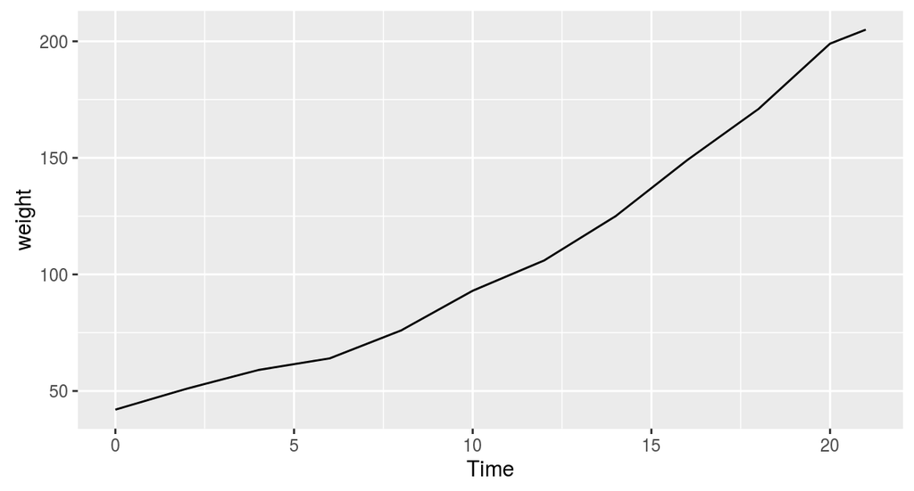

```r
ggplot(data=(ChickWeight %>% filter(Chick==1)), mapping=aes(x=Time, y=weight)) + geom_line()
```

Points can be easily added with `geom_point()`.

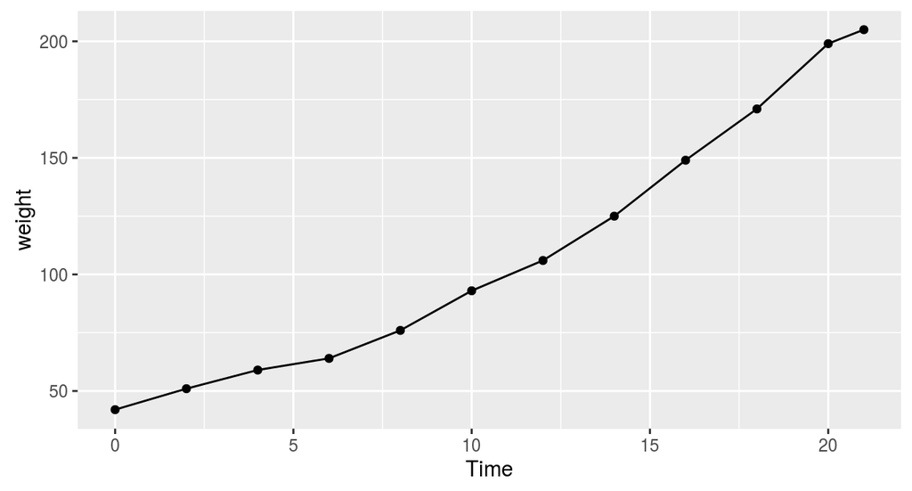

```r
ggplot(data=(ChickWeight %>% filter(Chick==1)), mapping=aes(x=Time, y=weight)) + geom_line() + geom_point()
```

You can change the appearance of the plot setting an aesthetic to a value. For example, the following plot has a dark blue line with squared and bigger points.

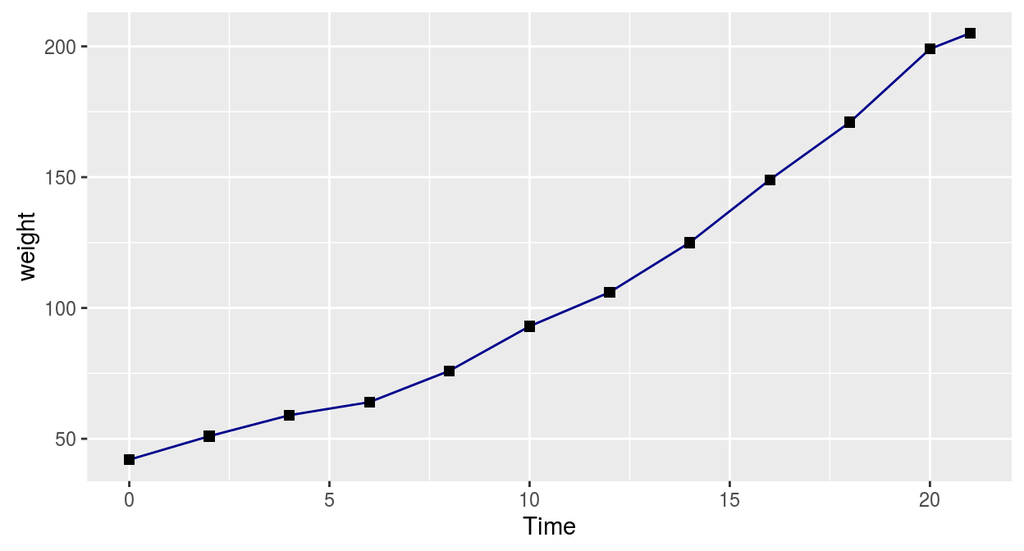

```r
ggplot(data=(ChickWeight %>% filter(Chick==1)), mapping=aes(x=Time, y=weight)) +
  geom_line(colour="darkblue") + geom_point(shape=15, size=2)
```

Available aesthetic are `x`, `y`, `alpha`, `colour` and `size` with the same (intuitive) meaning already seen for `geom_point()`.

To choose the style of the line you can use `linetype`. If you are experienced with R basic graphic, `linetype` has the same meaning that `lty`.

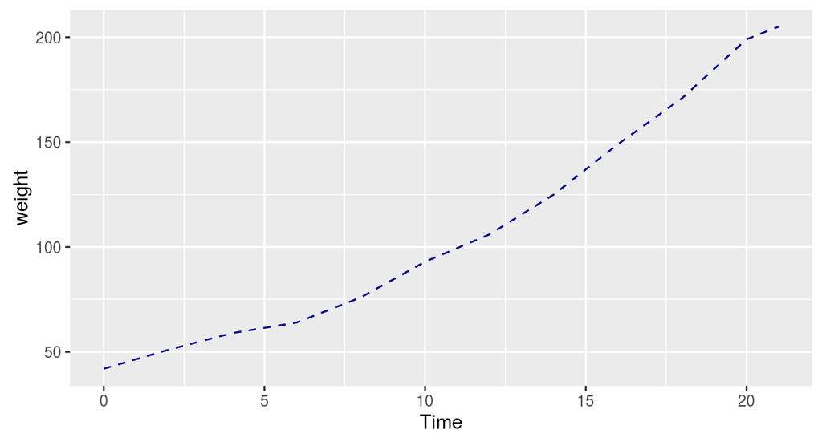

```r
ggplot(data=(ChickWeight %>% filter(Chick==1)), mapping=aes(x=Time, y=weight)) +
  geom_line(colour="darkblue", linetype=2)
```

The `linetype` can be a number (0-6) or a description (like `"solid"` or `"dashed"`). Available line types are:

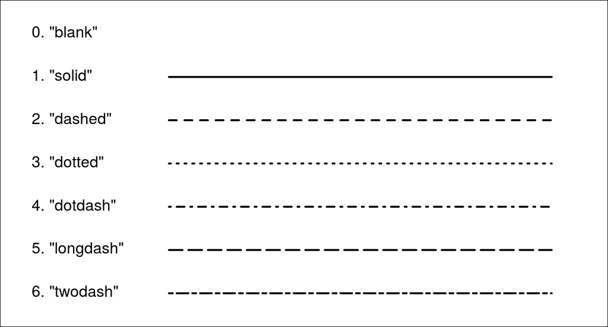

# Mapping variables to line graphs

If you are interested in the average growth of chicks for the different diets, you must first summarize data.

```r
ChickWeightMean <- ChickWeight %>% group_by(Time, Diet) %>% summarize(weight=mean(weight))
ChickWeightMean
```

```
## Source: local data frame [48 x 3]
## Groups: Time [?]
##
##     Time   Diet   weight
##    (dbl) (fctr)    (dbl)
## 1      0      1 41.40000
## 2      0      2 40.70000
## 3      0      3 40.80000
## 4      0      4 41.00000
## 5      2      1 47.25000
## 6      2      2 49.40000
## 7      2      3 50.40000
## 8      2      4 51.80000
## 9      4      1 56.47368
## 10     4      2 59.80000
## ..   ...    ...      ...
```

If you draw the same plot as above with new data, you will obtain a figure like this one.

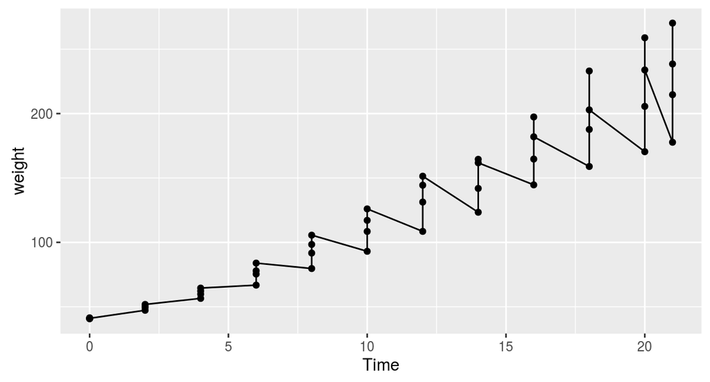

```r
ggplot(data=ChickWeightMean, mapping=aes(x=Time, y=weight)) +
  geom_line() + geom_point()
```

A jagged line appears when there are multiple data at each `x` and you tell ggplot to connect them. A plot like this one should sounds as a warning that something is wrong. In order to have a single point for each `x` you can summarize your data, or you can draw several lines, accordingly to a third variable, just adding a new aesthetic.

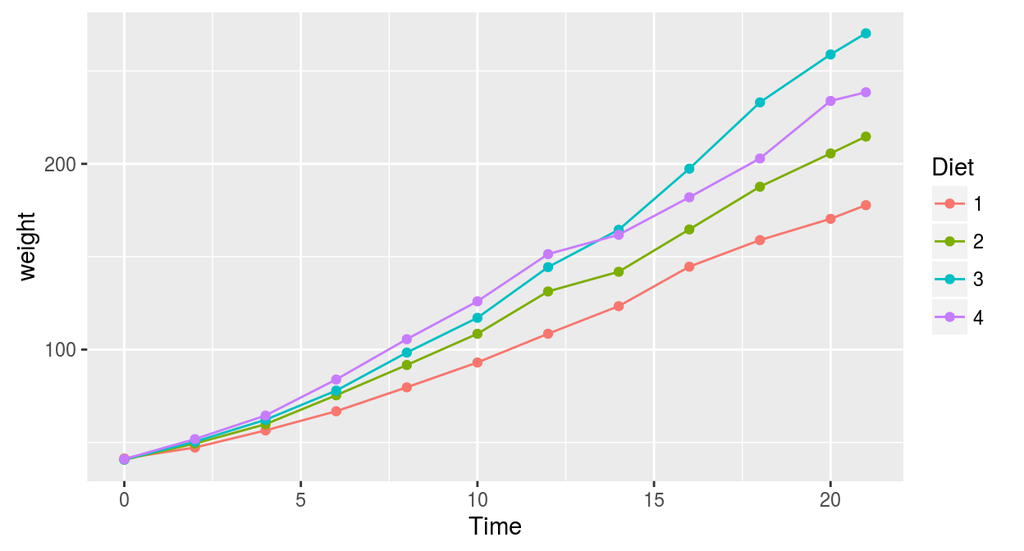

```r
ggplot(data=ChickWeightMean, mapping=aes(x=Time, y=weight, colour=Diet)) +
  geom_line() + geom_point()
```

Sometimes, the `x` variable can be a categorical variable. This is the case when you have numerical values that are conceived as categorical ones. The `ToothGrowth` data set can be a good case in point. Data can be summarized as follow:

```r
tg <- ToothGrowth %>% group_by(supp, dose) %>% summarize(length=mean(len))
tg
```

```
## Source: local data frame [6 x 3]
## Groups: supp [?]
##
##     supp  dose length
##   (fctr) (dbl)  (dbl)
## 1     OJ   0.5  13.23
## 2     OJ   1.0  22.70
## 3     OJ   2.0  26.06
## 4     VC   0.5   7.98
## 5     VC   1.0  16.77
## 6     VC   2.0  26.14
```

You can plot a line for each `supp` value:

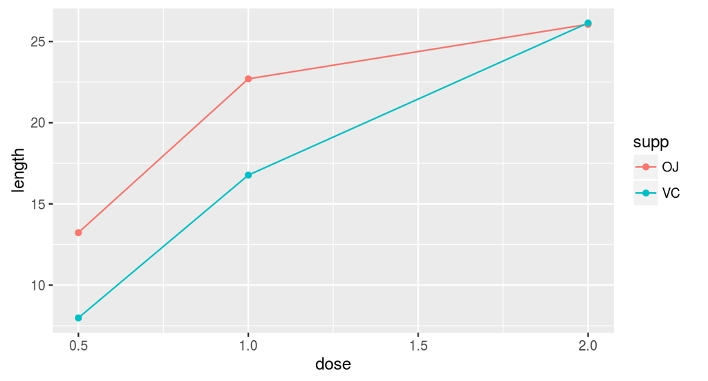

```r
ggplot(data=tg, mapping=aes(x=dose, y=length, colour=supp)) +
  geom_line() + geom_point()
```

The plot is good but since `dose` level are fixed the space between 0.5-1.0 and 1.0-2.0 should be the same. You can fix this issue, transforming `dose` into a factor.

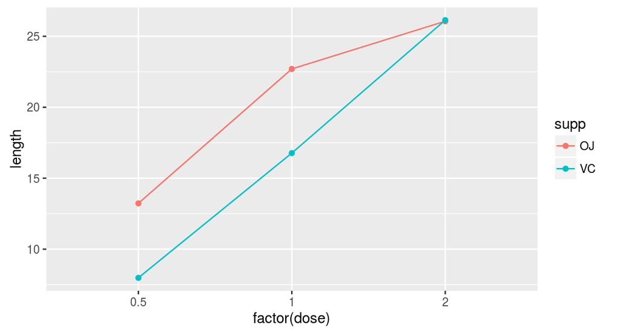

```r
ggplot(data=tg, mapping=aes(x=factor(dose), y=length, colour=supp, group=supp)) +
  geom_line() + geom_point()
```

Notice the use of `group=supp`. This is required to tell ggplot how to group data when it draws the lines. As [Hadley himself said](https://groups.google.com/forum/#!topic/ggplot2/Pwq6hO7r90w):

> The important thing [for a line graph with a factor on the horizontal axis] is to manually specify the grouping. By default `ggplot2` uses the combination of all categorical variables in the plot to group geoms - that doesn’t work for this plot because you get an individual line for each point. Manually specify `group = 1` indicates you want a single line connecting all the points.

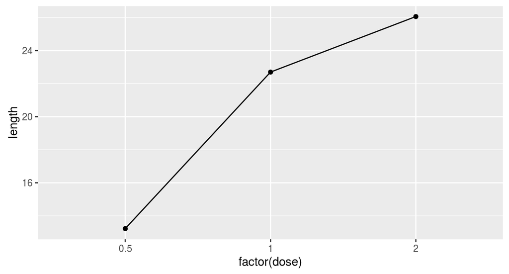

```r
ggplot(data=(tg%>%filter(supp=="OJ")), mapping=aes(x=factor(dose), y=length, group=1)) +
  geom_line() + geom_point()
```

When points overlap, you can *dodge* them. Dodging adjusts points left and right and must be applied to both lines and points, to avoid misalignment.

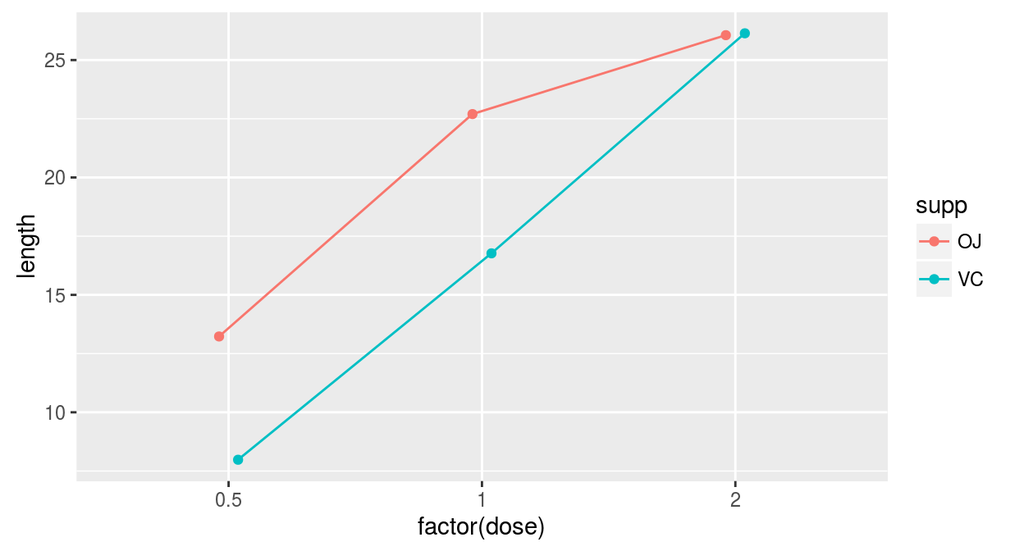

```r
ggplot(data=tg, mapping=aes(x=factor(dose), y=length, colour=supp, group=supp)) +
  geom_line(position=position_dodge(0.15)) + geom_point(position=position_dodge(0.15))
```

# Changing the Appearance of Mapped Aesthetics

When you feed your chicks, you use the “A” fodder for diet 1, the “B” fodder for diet 2, the “C” for diet 3 and the “D” for diet 4.

```r
ChickWeightMean <- ChickWeightMean %>% mutate(Diet = factor(Diet, levels=1:4, labels=c("A","B","C","D")))
```

“A” fodder is sold in red bags and farmers immediately identify this product with the red colour. In the same way, B is associated with the blue, C with the green and D with the orange. To improve the readability of the plot, lines for each diet should be of the colour that identify the fodder maker.

You cannot set the colour inside `ggplot()` or `geom_line()` using the `colour` argument, because this is admitted only when a variable is not *mapped* to the `colour` aesthetic. You can set manually the colour with the function `scale_colour_manual()`.

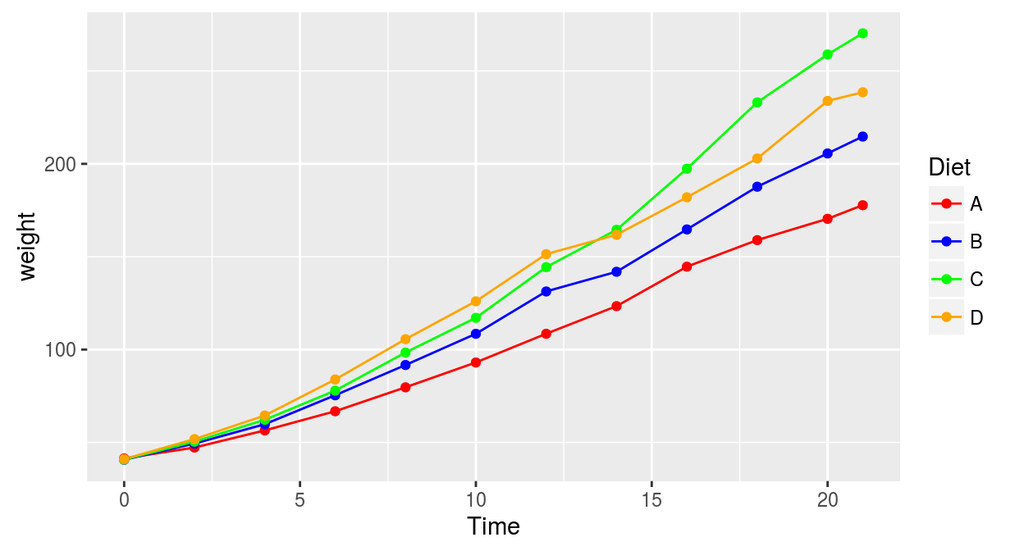

```r
ggplot(data=ChickWeightMean, mapping=aes(x=Time, y=weight, colour=Diet)) +
  geom_line() + geom_point() + scale_color_manual(values=c("red", "blue", "green", "orange"))
```

Colours in the `values` string vector must appear in the same order as they appear in the legend. You can pass a named vector to be sure of the correspondence between colour and data.

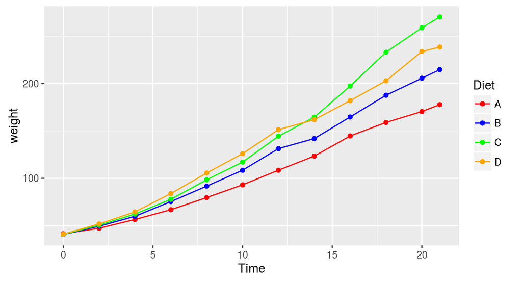

```r
ggplot(data=ChickWeightMean, mapping=aes(x=Time, y=weight, colour=Diet)) +
  geom_line() + geom_point() +
  scale_color_manual(values=c("D"="orange", "B"="blue", "A"="red", "C"="green"))
```

There are as many `scale_*_manual` function as aesthetics for which values can be set manually.

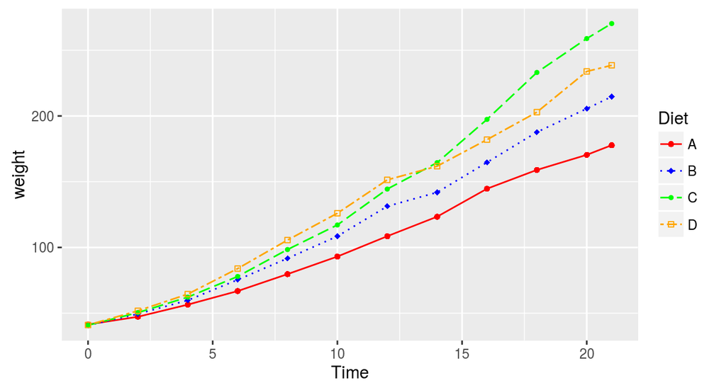

```r
ggplot(data=ChickWeightMean, mapping=aes(x=Time, y=weight, colour=Diet)) +
  geom_line(mapping=aes(linetype=Diet)) + geom_point(mapping=aes(shape=Diet)) +
  scale_color_manual(values=c("D"="orange", "B"="blue", "A"="red", "C"="green")) +
  scale_shape_manual(values=c(16,18,20,22)) +
  scale_linetype_manual(values=c(1,3,5,6))
```

# Adding horizontal and vertical lines

Line graphs often contains horizontal or vertical lines.

It may be interesting to analyse the average daily growth for each diet type.

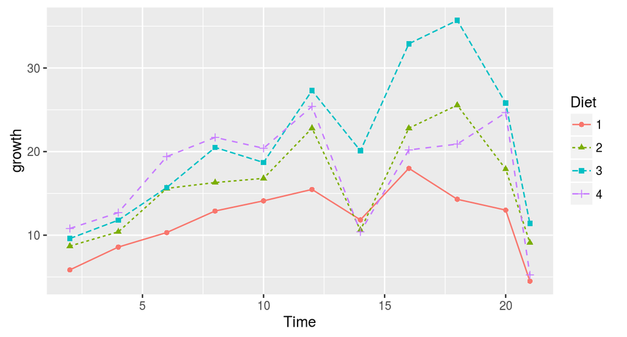

```r
ChickWeightGrowth <- ChickWeight %>% group_by(Chick) %>%
  mutate(growth=c(0,diff(weight))) %>% filter(growth != 0)

ChickWeightGrowthMean <- ChickWeightGrowth %>% group_by(Time, Diet) %>%
  summarize(growth=mean(growth))

ggp <- ggplot(data=ChickWeightGrowthMean, mapping=aes(x=Time, y=growth, colour=Diet)) +
  geom_line(mapping=aes(linetype=Diet)) + geom_point(mapping=aes(shape=Diet))

ggp
```

At this point you may want to add the average growth to the plot.

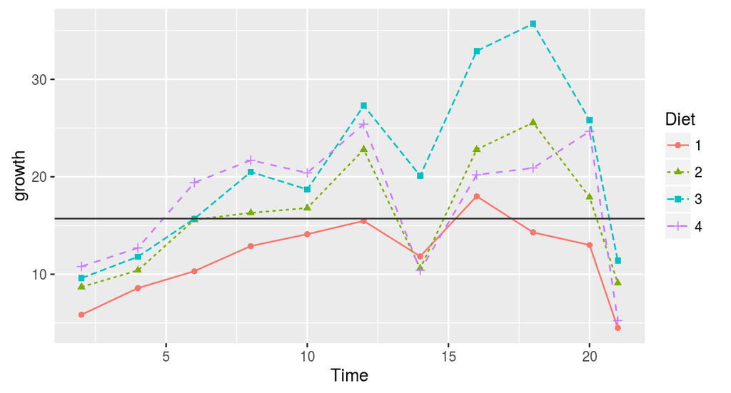

```r
growth_avg <- ChickWeightGrowth %>% magrittr::use_series(growth) %>% mean
ggp1 <- ggp + geom_hline(yintercept = growth_avg, colour="grey20")
ggp1
```

Data refers to a three-weeks period. It may be interesting to highlight each week adding a vertical line at days 7, 14 and 21.

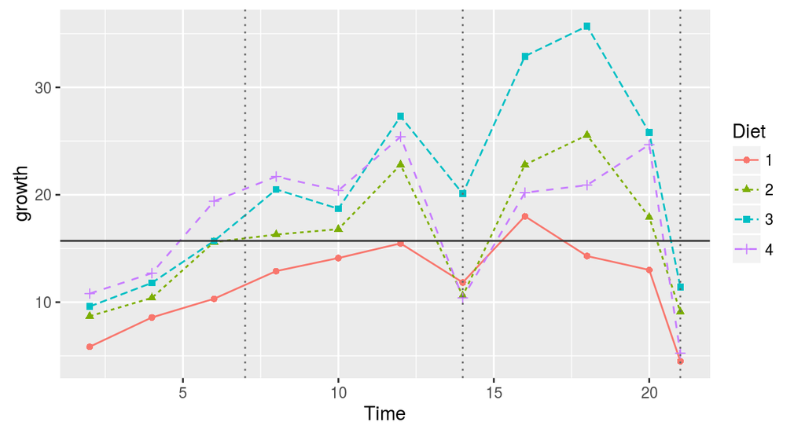

```r
ggp1 + geom_vline(xintercept = c(7,14,21), colour="grey40", linetype=3)
```